# Portfolio in R

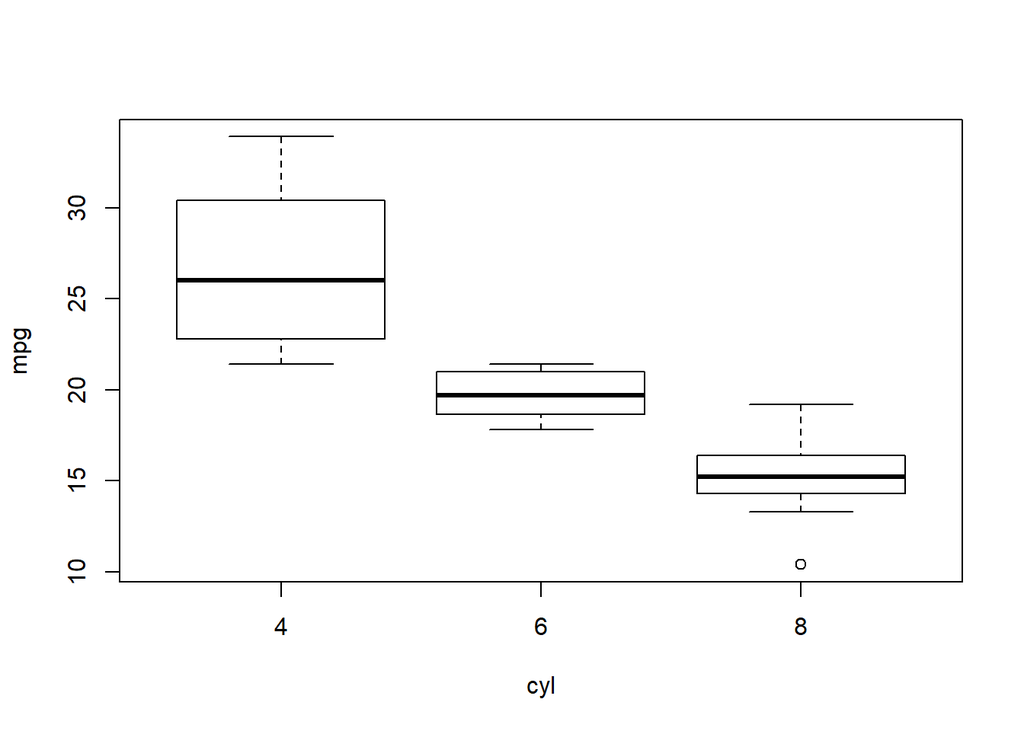

```r
boxplot(formula = mpg ~ cyl, data = mtcars)
```

20.Plot a histogram with the mtcars$mpg vector.

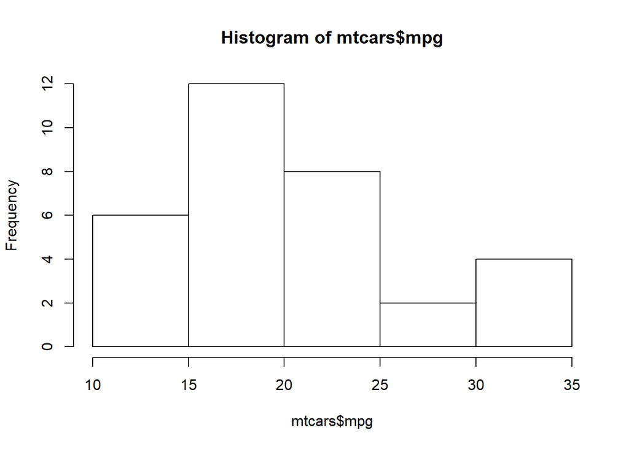

```r
hist(mtcars$mpg)
```

21.Using `if` and `else`, write a code that returns the string “number” if object x is of the numeric or integer class; the string “word” if the object is of the character class; and NULL otherwise.

```r
x <- 1

if(is.numeric(x)) {
  "número"
} else if(is.character(x)) {
  "palavra"
} else {
  NULL
}
```

```
[1] "número"
```

22.Use the for to return the minimum value of the following vector: vector <- c (4, 2, 1, 5, 3). Modify your code to receive vectors of any size.

```r
vetor <- c(4, 2, 1, 5, 3)
minimo <- Inf

for(i in 1:5) {

  if(minimo > vetor[i]) {
    minimo <- vetor[i]
  }

}

minimo
```

```
[1] 1
```

23.Using just for and the length() function, construct a function that averages any number vector. Construct a condition for the function to return NULL if the vector is not numeric.

```r
media <- function(x) {

  i <- 1
  tamanho <- length(x)
  soma <- 0

  for(i in 1:tamanho){
    soma <- soma + x[i]
  }

  return(soma/tamanho)
}

media(1:3)
```

```
[1] 2
```

24.Using iris data - no download required; to view the table use head (iris) -, construct a scatter plot with Sepal. Length on the x axis and Sepal. Width on the y axis. Name the x and y axes, use the title “Graf. 1” and add a red horizontal line at x=3.

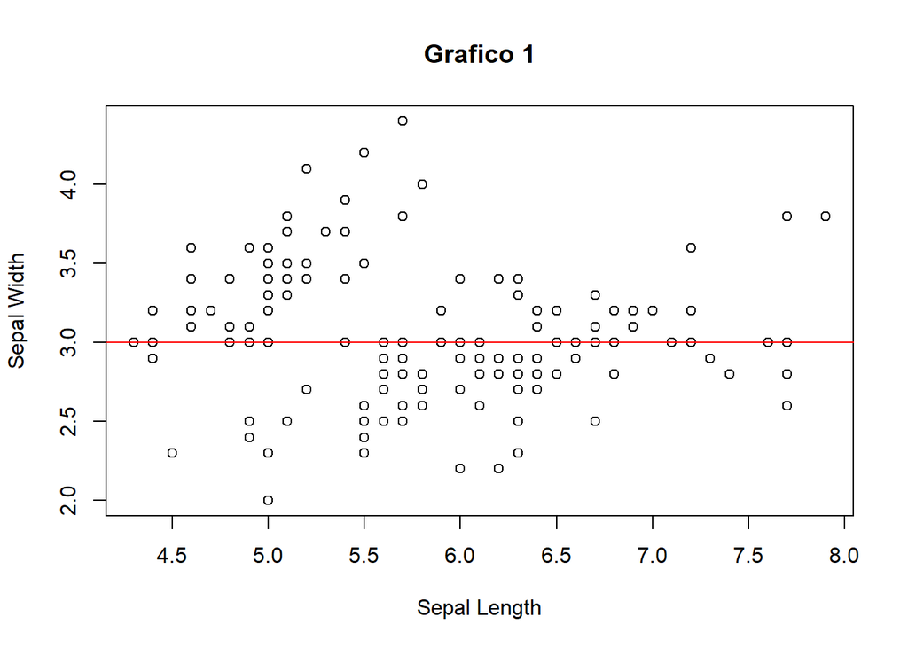

```r
# Plotting the graph
plot(iris$Sepal.Length,iris$Sepal.Width, xlab = "Sepal Length", ylab = "Sepal Width", main = "Grafico 1");
# Adding a red horizontal line
abline(h=3, col="red")
```

25.Still using iris, build a blue color histogram for Sepal.Length. Give the chart a title.

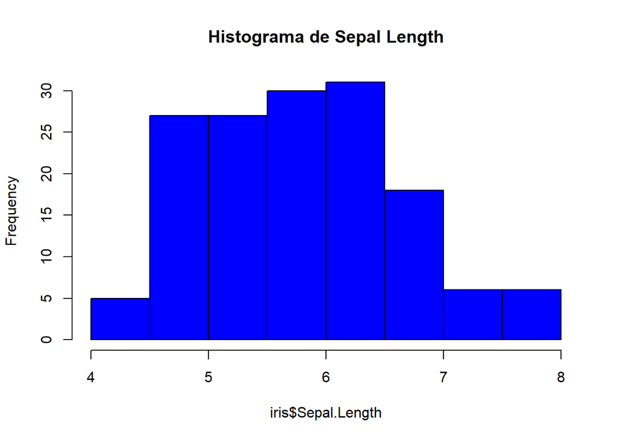

```r
hist(iris$Sepal.Length, col = "blue", main = "Histograma de Sepal Length")
```

```r
cor(iris[,-5])
```

```
             Sepal.Length Sepal.Width Petal.Length Petal.Width
Sepal.Length    1.0000000  -0.1175698    0.8717538   0.8179411
Sepal.Width    -0.1175698   1.0000000   -0.4284401  -0.3661259
Petal.Length    0.8717538  -0.4284401    1.0000000   0.9628654
Petal.Width     0.8179411  -0.3661259    0.9628654   1.0000000
```

27.Create a function where you input an number n and return the square of n as a result.

```r
SomaUm = function(x) {
y=x*x
return(y)
}

SomaUm(2)
```

```
[1] 4
```

28.Create a function whose input is two numbers, n and m, and which returns the sum and product of the two numbers. Make this function have m = 1 if the user does not assign any value to m;

```r
SomaProdutoN = function(x,m=1){
soma=x+m
prod=x*m
print(paste0("A soma é: ",soma))
print(paste0("O produto é: ",prod))
}

SomaProdutoN(1)
```

```
[1] "A soma é: 2"
[1] "O produto é: 1"
```

## ANALYZING DATA

Loading the dataset

Using the `read.csv()` function to load a .csv file

```r
planets = read.csv('C:/Users/LEONARDOTOZOBISINOTO/Documents/data/planets.csv',header=TRUE, sep=",")
```

```r
kable(head(planets), format = "html", row.names = TRUE) %>% kable_styling(bootstrap_options = c("striped", "hover"), full_width = F, font_size = 12, position = "left")
```

|  | planet | diameter | gravity | distance_from_sun | orbital_period | orbital_velocity | orbital_inclination | mean_temperature | number_of_moons |
| --- | --- | --- | --- | --- | --- | --- | --- | --- | --- |
| 1 | Mercury | 4879 | 3.7 | 57.9 | 88.0 | 47.4 | 7.0 | 167 | 0 |
| 2 | Venus | 12104 | 8.9 | 108.2 | 224.7 | 35.0 | 3.4 | 464 | 0 |
| 3 | Earth | 12756 | 9.8 | 149.6 | 365.2 | 29.8 | 0.0 | 15 | 1 |
| 4 | Mars | 6792 | 3.7 | 227.9 | 687.0 | 24.1 | 1.9 | -65 | 2 |
| 5 | Jupiter | 142984 | 23.1 | 778.6 | 4331.0 | 13.1 | 1.3 | -110 | 79 |
| 6 | Saturn | 120536 | 9.0 | 1433.5 | 10747.0 | 9.7 | 2.5 | -140 | 62 |

Exploring the dataset

```r
str(planets)
```

```
'data.frame':   9 obs. of  9 variables:
 $ planet             : Factor w/ 9 levels "Earth","Jupiter",..: 4 9 1 3 2 7 8 5 6
 $ diameter           : int  4879 12104 12756 6792 142984 120536 51118 49528 2370
 $ gravity            : num  3.7 8.9 9.8 3.7 23.1 9 8.7 11 0.7
 $ distance_from_sun  : num  57.9 108.2 149.6 227.9 778.6 ...
 $ orbital_period     : num  88 225 365 687 4331 ...
 $ orbital_velocity   : num  47.4 35 29.8 24.1 13.1 9.7 6.8 5.4 4.7
 $ orbital_inclination: num  7 3.4 0 1.9 1.3 2.5 0.8 1.8 17.2
 $ mean_temperature   : int  167 464 15 -65 -110 -140 -195 -200 -225
 $ number_of_moons    : int  0 0 1 2 79 62 27 14 5
```

```r
head(planets, n=3)
```

```
   planet diameter gravity distance_from_sun orbital_period
1 Mercury     4879     3.7              57.9           88.0
2   Venus    12104     8.9             108.2          224.7
3   Earth    12756     9.8             149.6          365.2
  orbital_velocity orbital_inclination mean_temperature number_of_moons
1             47.4                 7.0              167               0
2             35.0                 3.4              464               0
3             29.8                 0.0               15               1
```

```r
tail(planets, n=3)
```

```
   planet diameter gravity distance_from_sun orbital_period
7  Uranus    51118     8.7            2872.5          30589
8 Neptune    49528    11.0            4495.1          59800
9   Pluto     2370     0.7            5906.4          90560
  orbital_velocity orbital_inclination mean_temperature number_of_moons
7              6.8                 0.8             -195              27
8              5.4                 1.8             -200              14
9              4.7                17.2             -225               5
```

```r
summary(planets)
```

```
     planet     diameter         gravity       distance_from_sun
 Earth  :1   Min.   :  2370   Min.   : 0.700   Min.   :  57.9
 Jupiter:1   1st Qu.:  6792   1st Qu.: 3.700   1st Qu.: 149.6
 Mars   :1   Median : 12756   Median : 8.900   Median : 778.6
 Mercury:1   Mean   : 44785   Mean   : 8.733   Mean   :1781.1
 Neptune:1   3rd Qu.: 51118   3rd Qu.: 9.800   3rd Qu.:2872.5
 Pluto  :1   Max.   :142984   Max.   :23.100   Max.   :5906.4
 (Other):3
 orbital_period    orbital_velocity orbital_inclination mean_temperature
 Min.   :   88.0   Min.   : 4.70    Min.   : 0.000      Min.   :-225.00
 1st Qu.:  365.2   1st Qu.: 6.80    1st Qu.: 1.300      1st Qu.:-195.00
 Median : 4331.0   Median :13.10    Median : 1.900      Median :-110.00
 Mean   :21932.4   Mean   :19.56    Mean   : 3.989      Mean   : -32.11
 3rd Qu.:30589.0   3rd Qu.:29.80    3rd Qu.: 3.400      3rd Qu.:  15.00
 Max.   :90560.0   Max.   :47.40    Max.   :17.200      Max.   : 464.00

 number_of_moons
 Min.   : 0.00
 1st Qu.: 1.00
 Median : 5.00
 Mean   :21.11
 3rd Qu.:27.00
 Max.   :79.00
```

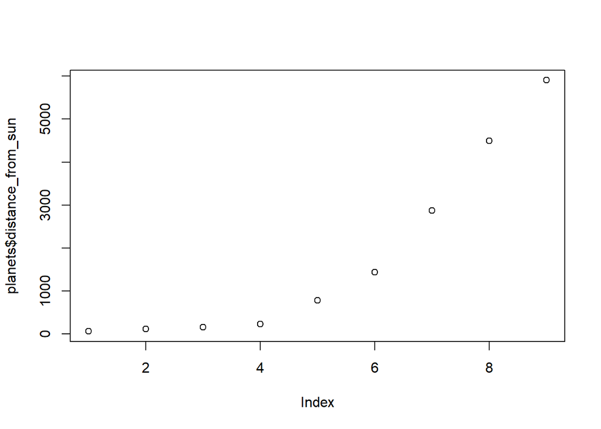

```r
plot(planets$distance_from_sun)
```

```r
kable(planets$planet, col.names = c("Planets"))
```

| Planets |
| --- |
| Mercury |
| Venus |
| Earth |
| Mars |
| Jupiter |
| Saturn |
| Uranus |
| Neptune |
| Pluto |

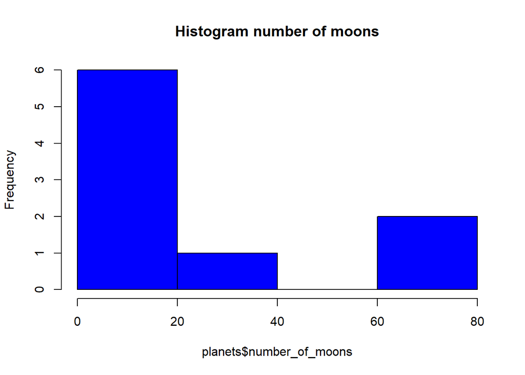

```r
hist(planets$number_of_moons, col = "blue", main = "Histogram number of moons")
```

*Leonardo Tozo Bisinoto - São Paulo - 2020*